# Genre Classification using Spotify Metadata

## Correlation Between Continuous Independent Variables

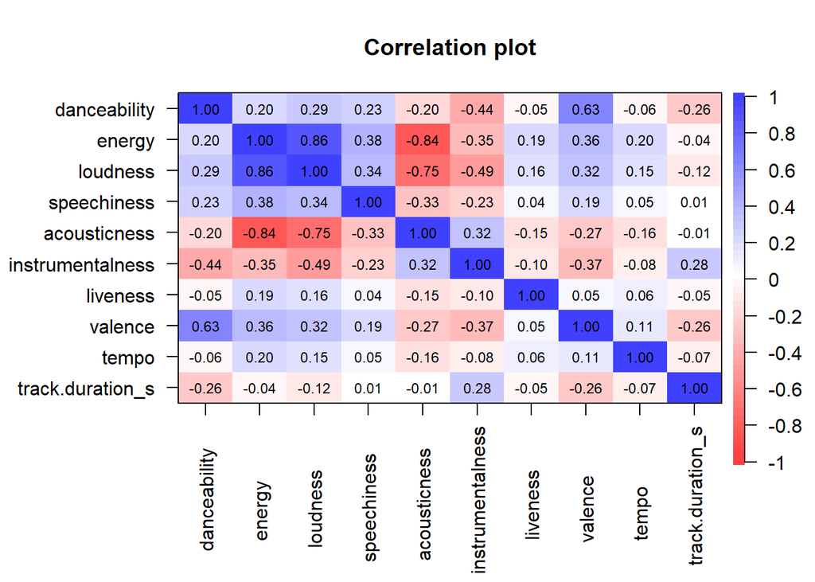

High correlation between independent variables can pose a problem during the construction of a machine learning model. Many sources state that it can be considered high if it exceeds the value of 0.7. In our dataset, this value is exceeded three times, between pairs of variables:

- energy-loudness,
- energy-acousticness,
- loudness-acousticness.

**energy vs. loudness**

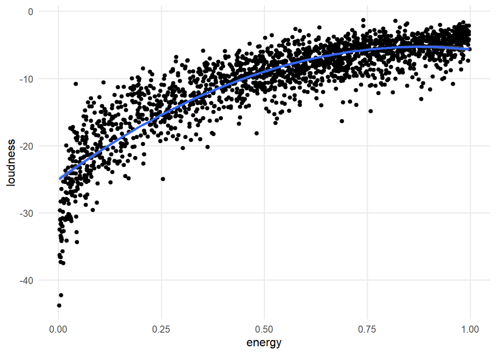

**energy vs. acousticness**

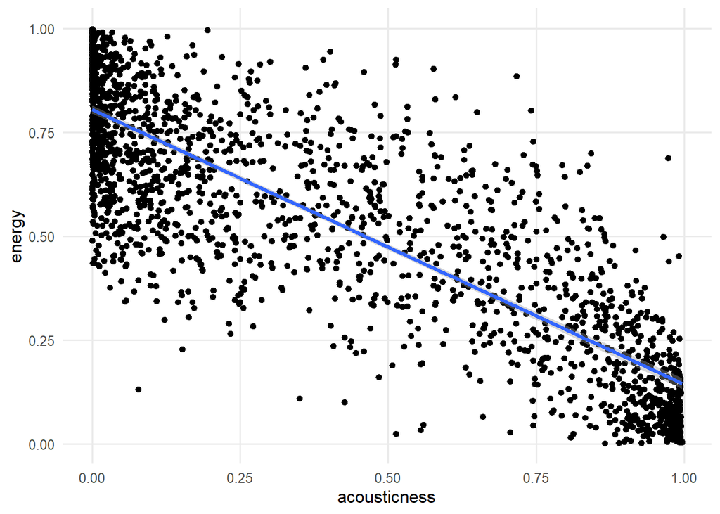

**loudness vs. acousticness**

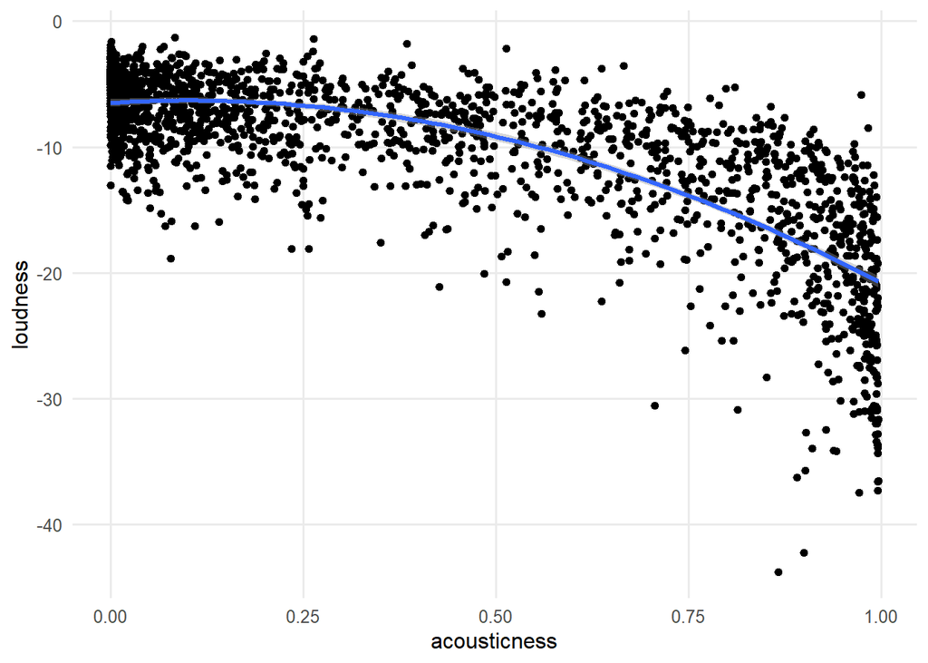

The charts between these variables show uncovered relationships, especially in the case of energy and loudness, where the observations quite clearly align along a curve fitted with a second-degree polynomial.

[interactive chart not shown]

The three-dimensional chart shows how much these three features depend on each other.

To check if it will be possible to replace these three variables with just one of them, I will perform PCA to reduce three dimensions to one, and then check which of these variables has the greatest impact on shaping this dimension.

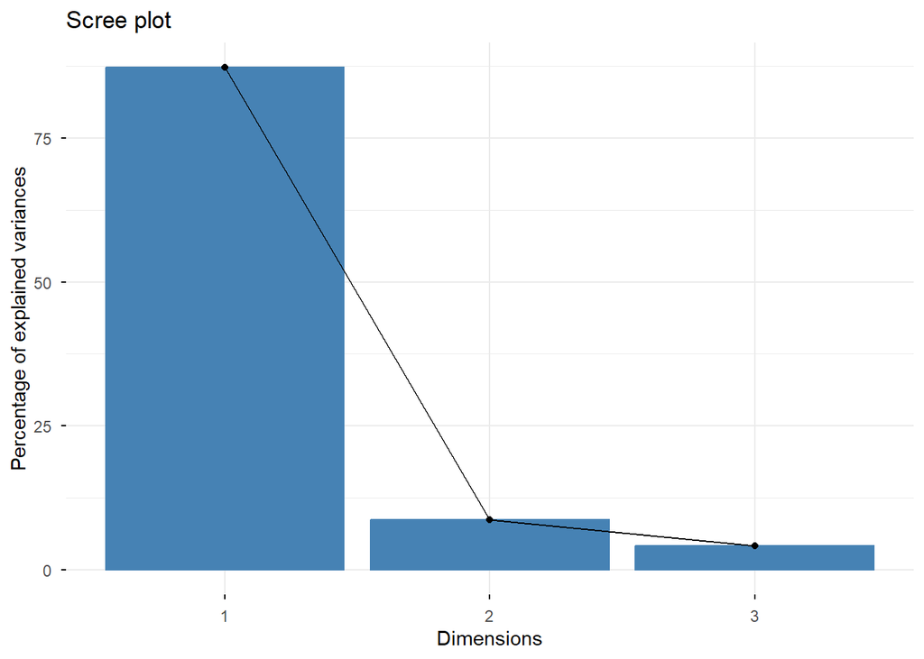

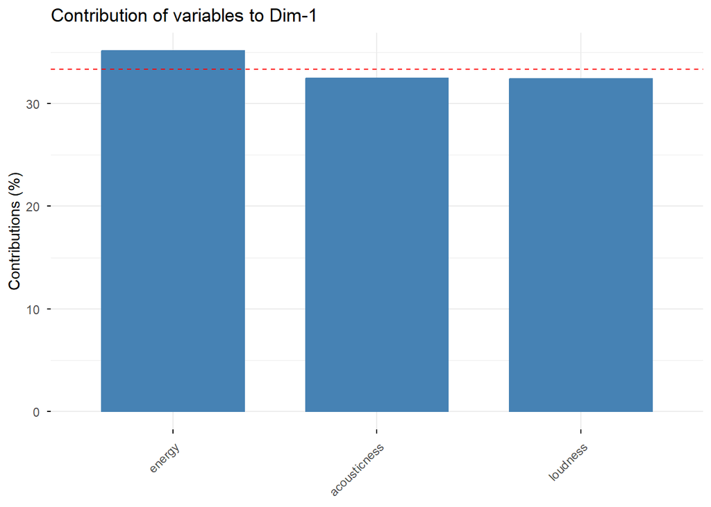

The variable contribution chart for the first dimension and the cutoff line suggest that the `energy` variable has the most significant impact on creating this dimension. On this basis, I therefore decide to leave only `energy` from the trio of variables `energy`, `acousticness`, and `loudness`, which will eliminate the problem of high correlation between some of the dependent variables in the dataset. Later on, however, I will also check how a model built on the dataset with the removed variables will perform. “High correlation” is indeed a fluid term - some sources say it starts at 0.7, while sometimes high correlation is spoken of only from 0.9. So there is a chance that the correlation that occurred here had no impact on the future predictive efficacy of the model.

**Display code**

```r
df2 <- df

df <- df %>%
  select(-c(loudness, acousticness))
```

# Preparing the Multi-class Classification Model

The dataset no longer contains missing data or duplicates, the selected variables are correctly encoded and contain no irregularities, and the problem of high correlation has been eliminated, so we can move on to preparing the model predicting the musical genre.

## Splitting the Dataset into Training and Test Sets

I split the dataset into training and test sets in a 0.8 proportion, setting the `strata` parameter to the value “genre”, so that the proportions of the dependent variable’s group sizes are preserved.

**Display code**

```r
set.seed(170)

split <- initial_split(df, prop = 0.8, strata = genre)
spotify_train <- training(split)
spotify_test <- testing(split)
split
```

```
<Training/Testing/Total>
<1614/408/2022>
```

## Preparing 10-fold Cross-validation

**Display code**

```r
spotify_folds <- vfold_cv(spotify_train, strata = genre)
spotify_folds
```

```
#  10-fold cross-validation using stratification
# A tibble: 10 × 2
   splits             id
   <list>             <chr>
 1 <split [1448/166]> Fold01
 2 <split [1450/164]> Fold02
 3 <split [1452/162]> Fold03
 4 <split [1453/161]> Fold04
 5 <split [1453/161]> Fold05
 6 <split [1453/161]> Fold06
 7 <split [1454/160]> Fold07
 8 <split [1454/160]> Fold08
 9 <split [1454/160]> Fold09
10 <split [1455/159]> Fold10
```

## Preparing Appropriate Recipes

The table below presents the models I intend to use to build predictive models based on my dataset, as well as the type of preprocessing that is recommended for them.

| Model | Dummy vars | Zero-variance | Decorrelate | Normalize | Transform |
| --- | --- | --- | --- | --- | --- |
| Random forest | ✗ | ◌ | ◌ | ✗ | ✗ |
| Bagging | ✗ | ✗ | ◌ | ✗ | ✗ |
| XGBoost | ✗ | ◌ | ◌ | ✗ | ✗ |
| Mlp | ✓ | ✓ | ✓ | ✓ | ✓ |
| Knn | ✓ | ✓ | ◌ | ✓ | ✓ |
| Svm | ✓ | ✓ | ✓ | ✓ | ✓ |
| Naive Bayes | ✗ | ✓ | ◌ | ✗ | ✗ |

Preprocessing types:

- dummy vars - converting categorical variables into so-called dummy variables
- zero-variance - removing variables that contain only a single value
- decorrelate - eliminating the problem of high correlation between explanatory variables
- normalize - normalization
- transform - forcing greater distribution symmetry of asymmetric variables

✓ means that a given type of preprocessing is recommended, ✗ - the opposite, whereas ◌ means that a given procedure may, but does not have to, help in achieving better results.

The dataset after prior procedures no longer has a high correlation problem, so it does not require further “decorrelation”. It also does not contain variables comprising a single value, but I will include this preprocessing element in the recipes just in case.

Based on the table, I create three recipes:

- `basic_recipe` specifies the predictors and the explained variable in the model, gives the `track_name` variable a different role so it cannot be used in training the model, and potential variables taking a single value are removed,
- `dummy_recipe` additionally converts categorical variables into dummy variables,
- `transform_recipe` additionally transforms numeric variables using the Yeo-Johnson transformation and normalizes them.

**Display code**

```r
basic_recipe <-
  recipe(genre~., data = spotify_train) %>%
  update_role(track.name, new_role = "track_name") %>%
  step_zv(all_predictors())
```

```
# A tibble: 15 × 4
   variable         type      role       source
   <chr>            <list>    <chr>      <chr>
 1 danceability     <chr [2]> predictor  original
 2 energy           <chr [2]> predictor  original
 3 key              <chr [3]> predictor  original
 4 mode             <chr [3]> predictor  original
 5 speechiness      <chr [2]> predictor  original
 6 instrumentalness <chr [2]> predictor  original
 7 liveness         <chr [2]> predictor  original
 8 valence          <chr [2]> predictor  original
 9 tempo            <chr [2]> predictor  original
10 time_signature   <chr [3]> predictor  original
11 track.explicit   <chr [3]> predictor  original
12 track.name       <chr [3]> track_name original
13 decade           <chr [3]> predictor  original
14 track.duration_s <chr [2]> predictor  original
15 genre            <chr [3]> outcome    original
```

**Display code**

```r
dummy_recipe <-
  basic_recipe %>%
  step_dummy(all_nominal_predictors())
```

**Display code**

```r
transform_recipe <-
  dummy_recipe %>%
  step_YeoJohnson(all_numeric_predictors()) %>%
  step_normalize(all_numeric_predictors())
```

| variable | type | role | source |
| --- | --- | --- | --- |
| danceability | double , numeric | predictor | original |
| energy | double , numeric | predictor | original |
| speechiness | double , numeric | predictor | original |
| instrumentalness | double , numeric | predictor | original |
| liveness | double , numeric | predictor | original |
| valence | double , numeric | predictor | original |
| tempo | double , numeric | predictor | original |
| track.name | string , unordered, nominal | track_name | original |
| track.duration_s | double , numeric | predictor | original |
| genre | factor , unordered, nominal | outcome | original |
| key_X1 | double , numeric | predictor | derived |
| key_X2 | double , numeric | predictor | derived |
| key_X3 | double , numeric | predictor | derived |
| key_X4 | double , numeric | predictor | derived |
| key_X5 | double , numeric | predictor | derived |
| key_X6 | double , numeric | predictor | derived |
| key_X7 | double , numeric | predictor | derived |
| key_X8 | double , numeric | predictor | derived |
| key_X9 | double , numeric | predictor | derived |
| key_X10 | double , numeric | predictor | derived |
| key_X11 | double , numeric | predictor | derived |
| mode_X1 | double , numeric | predictor | derived |
| time_signature_other | double , numeric | predictor | derived |
| track.explicit_X1 | double , numeric | predictor | derived |
| decade_X70 | double , numeric | predictor | derived |
| decade_X80 | double , numeric | predictor | derived |
| decade_X90 | double , numeric | predictor | derived |
| decade_X00 | double , numeric | predictor | derived |
| decade_X10 | double , numeric | predictor | derived |
| decade_X20 | double , numeric | predictor | derived |

## Defining Models and Preparing Their Parameters for Tuning

**Display code**

```r
rf_spec <- rand_forest(mtry = tune(), min_n = tune(), trees = tune()) %>%
  set_engine("ranger") %>%
  set_mode("classification")

bagging_spec <- bag_tree(min_n = tune(), tree_depth = tune()) %>%
  set_engine("rpart", times = 60L) %>%
  set_mode("classification")

xgb_spec <- boost_tree(mtry = tune(), trees = tune(), min_n = tune(), tree_depth = tune(), learn_rate = tune(), loss_reduction = tune(), sample_size = tune()) %>%
  set_engine("xgboost") %>%
  set_mode("classification")

mlp_spec <-
  mlp(hidden_units = tune(), penalty = tune(), epochs = tune()) %>%
  set_engine("nnet", trace = 0) %>%
  set_mode("classification")

nearest_spec <- nearest_neighbor(neighbors = tune(), weight_func = tune(), dist_power = tune()) %>%
  set_engine("kknn") %>%
  set_mode("classification")

svm_spec <- svm_rbf(cost = tune(), rbf_sigma = tune()) %>%
  set_engine("kernlab") %>%
  set_mode("classification")

bayes_spec <- naive_Bayes(smoothness = tune(), Laplace = tune()) %>%
  set_engine("klaR") %>%
  set_mode("classification")
```

## Assigning Models to Appropriate Workflows

**Display code**

```r
basic <- workflow_set(preproc = list(basic = basic_recipe),
                      models = list(random_forest = rf_spec,
                                    bagging = bagging_spec,
                                    naive_bayes = bayes_spec))
```

**Display code**

```r
dummy <- workflow_set(preproc = list(dummy = dummy_recipe),
                      models = list(xgb = xgb_spec))
```

**Display code**

```r
transform <- workflow_set(preproc = list(transform = transform_recipe),
                          models = list(mlp = mlp_spec,
                                        knn = nearest_spec,
                                        svm = svm_spec))
```

**Display code**

```r
all_workflows <- bind_rows(basic, dummy, transform) %>%
  mutate(wflow_id = gsub("(basic_)|(dummy_)|(transform_)", "", wflow_id))
```

```
# A workflow set/tibble: 7 × 4
  wflow_id      info             option    result
  <chr>         <list>           <list>    <list>
1 random_forest <tibble [1 × 4]> <opts[0]> <list [0]>
2 bagging       <tibble [1 × 4]> <opts[0]> <list [0]>
3 naive_bayes   <tibble [1 × 4]> <opts[0]> <list [0]>
4 xgb           <tibble [1 × 4]> <opts[0]> <list [0]>
5 mlp           <tibble [1 × 4]> <opts[0]> <list [0]>
6 knn           <tibble [1 × 4]> <opts[0]> <list [0]>
7 svm           <tibble [1 × 4]> <opts[0]> <list [0]>
```

## Tuning Model Hyperparameters

I will use the following metrics when searching for the best model with the best parameters: accuracy, bal_accuracy, precision, recall, sensitivity, and specificity.

**Display code**

```r
grid_ctrl <-
  control_grid(
    save_pred = TRUE,
    parallel_over = "everything",
    save_workflow = TRUE)
```

**Display code**

```r
cl <- makePSOCKcluster(4)
registerDoParallel(cl)

grid_results <-
 all_workflows %>%
 workflow_map(seed = 170,
              resamples = spotify_folds,
              grid = 25,
              metrics = metric_set(accuracy, bal_accuracy, precision, recall, sensitivity, specificity),
              control = grid_ctrl)

stopCluster(cl)
registerDoSEQ()
```

Using the same steps, I will also find the best parameters for the dataset in which I did not remove the `loudness` and `acousticness` variables. The data split into training and test sets will be the same, so it will be possible to see where the models differed.

**Display code**

```r
set.seed(170)

split2 <- initial_split(df2, prop = 0.8, strata = genre)
spotify_train2 <- training(split2)
spotify_test2 <- testing(split2)

spotify_folds2 <- vfold_cv(spotify_train2, strata = genre)

basic_recipe2 <-
  recipe(genre~., data = spotify_train2) %>%
  update_role(track.name, new_role = "track_name") %>%
  step_zv(all_predictors())

dummy_recipe2 <-
  basic_recipe2 %>%
  step_dummy(all_nominal_predictors())

transform_recipe2 <-
  dummy_recipe2 %>%
  step_YeoJohnson(all_numeric_predictors()) %>%
  step_normalize(all_numeric_predictors())

basic2 <- workflow_set(preproc = list(basic = basic_recipe2),
                      models = list(random_forest = rf_spec,
                                    bagging = bagging_spec,
                                    naive_bayes = bayes_spec))

dummy2 <- workflow_set(preproc = list(dummy = dummy_recipe2),
                      models = list(xgb = xgb_spec))

transform2 <- workflow_set(preproc = list(transform = transform_recipe2),
                          models = list(mlp = mlp_spec,
                                        knn = nearest_spec,
                                        svm = svm_spec))

all_workflows2 <- bind_rows(basic2, dummy2, transform2) %>%
  mutate(wflow_id = gsub("(basic_)|(dummy_)|(transform_)", "", wflow_id))
```

**Display code**

```r
grid_ctrl2 <-
  control_grid(
    save_pred = TRUE,
    parallel_over = "everything",
    save_workflow = TRUE)

cl <- makePSOCKcluster(4)
registerDoParallel(cl)

grid_results2 <-
 all_workflows2 %>%
 workflow_map(seed = 170,
              resamples = spotify_folds2,
              grid = 25,
              metrics = metric_set(accuracy, bal_accuracy, precision, recall, sensitivity, specificity),
              control = grid_ctrl2)

stopCluster(cl)
registerDoSEQ()
```

## Tuning Results

**Dataset without `loudness` and `acousticness**

```
# A tibble: 6 × 3
  wflow_id      .metric       mean
  <chr>         <chr>        <dbl>
1 random_forest accuracy     0.763
2 random_forest bal_accuracy 0.862
3 random_forest precision    0.759
4 random_forest recall       0.753
5 random_forest sensitivity  0.753
6 random_forest specificity  0.970
```

**Dataset with these variables**

```
# A tibble: 6 × 3
  wflow_id      .metric       mean
  <chr>         <chr>        <dbl>
1 random_forest accuracy     0.783
2 random_forest bal_accuracy 0.873
3 random_forest precision    0.783
4 random_forest recall       0.772
5 random_forest sensitivity  0.772
6 random_forest specificity  0.973
```

It looks like, according to every metric, the random forest model turns out to be the best. Additionally, it looks like the model built on the dataset with the `loudness` and `acousticness` variables is marginally better.

**Dataset without `loudness` and `acousticness**

```
# A tibble: 6 × 2
  wflow_id      bal_accuracy
  <chr>                <dbl>
1 random_forest        0.862
2 random_forest        0.860
3 random_forest        0.861
4 random_forest        0.860
5 random_forest        0.860
6 random_forest        0.860
```

**Dataset with these variables**

```
# A tibble: 6 × 2
  wflow_id      bal_accuracy
  <chr>                <dbl>
1 random_forest        0.873
2 random_forest        0.872
3 random_forest        0.872
4 random_forest        0.871
5 random_forest        0.871
6 random_forest        0.870
```

After adopting `balanced accuracy` as the main comparative metric, the random forest model also definitively looks like the best. Thus, at this stage, it can be assumed that eliminating the correlation did not improve the model, and even slightly worsened it, which I will ultimately verify later by checking the accuracy of each model on the test set.

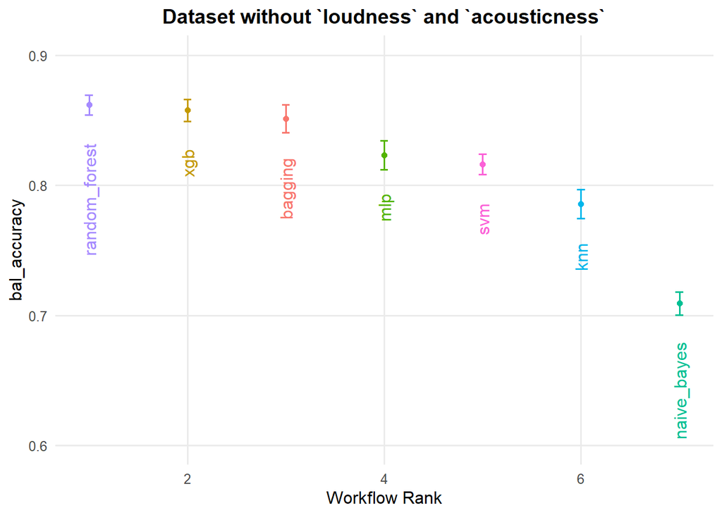

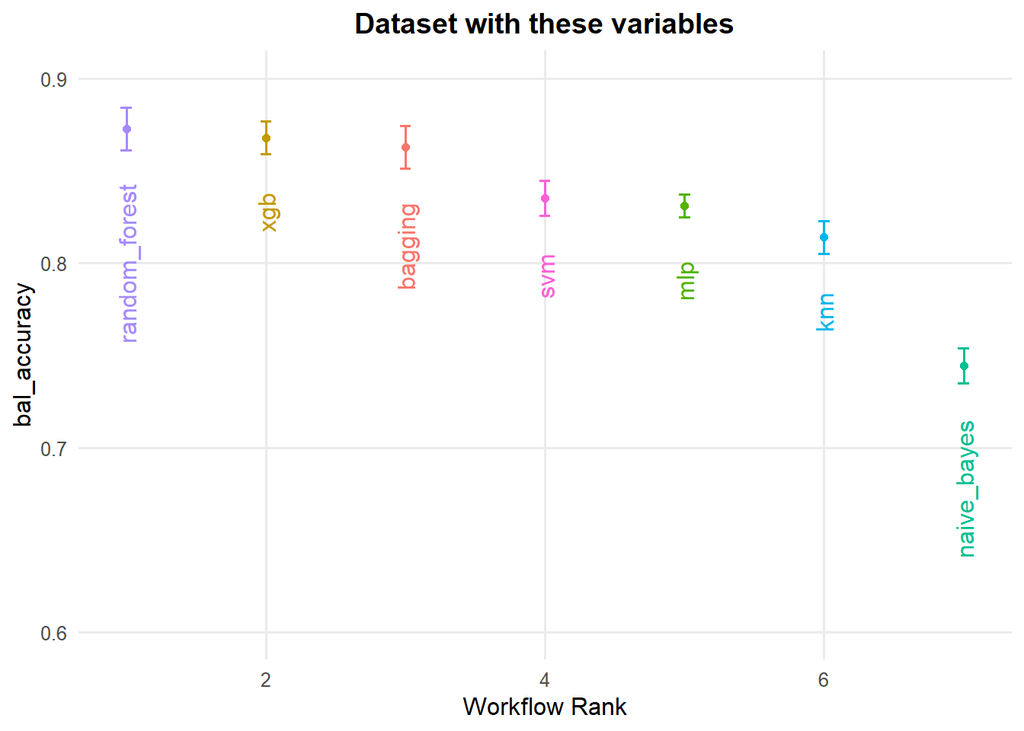

```
# A tibble: 7 × 2
  model            bal_accuracy
  <chr>                   <dbl>
1 rand_forest             0.862
2 boost_tree              0.858
3 bag_tree                0.851
4 mlp                     0.823
5 svm_rbf                 0.816
6 nearest_neighbor        0.786
7 naive_Bayes             0.709
```

```
# A tibble: 7 × 2
  model            bal_accuracy
  <chr>                   <dbl>
1 rand_forest             0.873
2 boost_tree              0.868
3 bag_tree                0.863
4 svm_rbf                 0.835
5 mlp                     0.831
6 nearest_neighbor        0.814
7 naive_Bayes             0.744
```

The comparison of the best model of each type confirms that in our task, “tree-based” models performed best, whereas the naive Bayes classifier performed the poorest. Additionally, it is clearly visible that keeping the previously removed variables improved the average accuracy of each model. The order of models depending on the dataset used, from most accurate to least accurate, is also similar - only the SVM model turned out to be marginally better and overtook the MLP model in the case of models built using the dataset with more variables.

## Creating the Best Models with Parameters Selected by Grid Search

Ultimately, I decide to create two random forest models for each dataset, because it performed best in every comparison. I will from now on designate the model without additional variables as `Model1`, while the second one will be designated as `Model2`.

**Display code**

```r
best_results <-
  grid_results %>%
  extract_workflow_set_result("random_forest") %>%
  select_best(metric = "bal_accuracy")

best_results2 <-
  grid_results2 %>%
  extract_workflow_set_result("random_forest") %>%
  select_best(metric = "bal_accuracy")
```

**Model1**

```
# A tibble: 1 × 3
   mtry trees min_n
  <int> <int> <int>
1     3  1871     5
```

**Model2**

```
# A tibble: 1 × 3
   mtry trees min_n
  <int> <int> <int>
1     6  1927     5
```

The random forest models selected by grid search have the following parameters, respectively:

- `mtry` = 3,
- `trees` = 1871,
- `min_n` = 5

for `Model1` and

- `mtry` = 6,
- `trees` = 1927,
- `min_n` = 5

for `Model2`.

**Display code**

```r
best_model_random_forest <- rand_forest(trees = best_results$trees,
                             mtry = best_results$mtry,
                             min_n = best_results$min_n) %>%
  set_engine("ranger", importance = "impurity") %>%
  set_mode("classification")

best_model_random_forest2 <- rand_forest(trees = best_results2$trees,
                             mtry = best_results2$mtry,
                             min_n = best_results2$min_n) %>%
  set_engine("ranger", importance = "impurity") %>%
  set_mode("classification")
```

## Checking Model Accuracy on the Test Set

Ultimately, one can find out which model performs more accurately and what the actual predictive capability of the built models is by checking their capabilities on the test set.

**Display code**

```r
rf_wflow <-
  workflow() %>%
  add_model(best_model_random_forest) %>%
  add_recipe(basic_recipe)

rf_fit <-
  rf_wflow %>%
  fit(data = spotify_train)

rf_wflow2 <-
  workflow() %>%
  add_model(best_model_random_forest2) %>%
  add_recipe(basic_recipe2)

rf_fit2 <-
  rf_wflow2 %>%
  fit(data = spotify_train2)
```

**Display code**

```r
test_pred <- predict(rf_fit, new_data = spotify_test) %>%
  bind_cols(spotify_test)

metrics_set <- metric_set(accuracy, bal_accuracy, precision, recall, sensitivity, specificity)

metrics_test <- metrics_set(test_pred,
                    truth = genre, estimate = .pred_class)

test_pred2 <- predict(rf_fit2, new_data = spotify_test2) %>%
  bind_cols(spotify_test2)

metrics_test2 <- metrics_set(test_pred2,
                    truth = genre, estimate = .pred_class)
```

**Model1**

```
# A tibble: 6 × 3
  .metric      .estimator .estimate
  <chr>        <chr>          <dbl>
1 accuracy     multiclass     0.733
2 bal_accuracy macro          0.845
3 precision    macro          0.727
4 recall       macro          0.723
5 sensitivity  macro          0.723
6 specificity  macro          0.967
```

**Model2**

```
# A tibble: 6 × 3
  .metric      .estimator .estimate
  <chr>        <chr>          <dbl>
1 accuracy     multiclass     0.782
2 bal_accuracy macro          0.872
3 precision    macro          0.772
4 recall       macro          0.772
5 sensitivity  macro          0.772
6 specificity  macro          0.973
```

When comparing metrics on the test sets, it is ultimately apparent that `Model2` has better generalization capabilities. A `bal_accuracy` metric value of 0.87 is satisfactory and means the model handles data it hasn’t seen before well. The difference between the metrics of both models is not very large, but it will certainly be noticeable on the classification matrix.

### Confusion Matrices

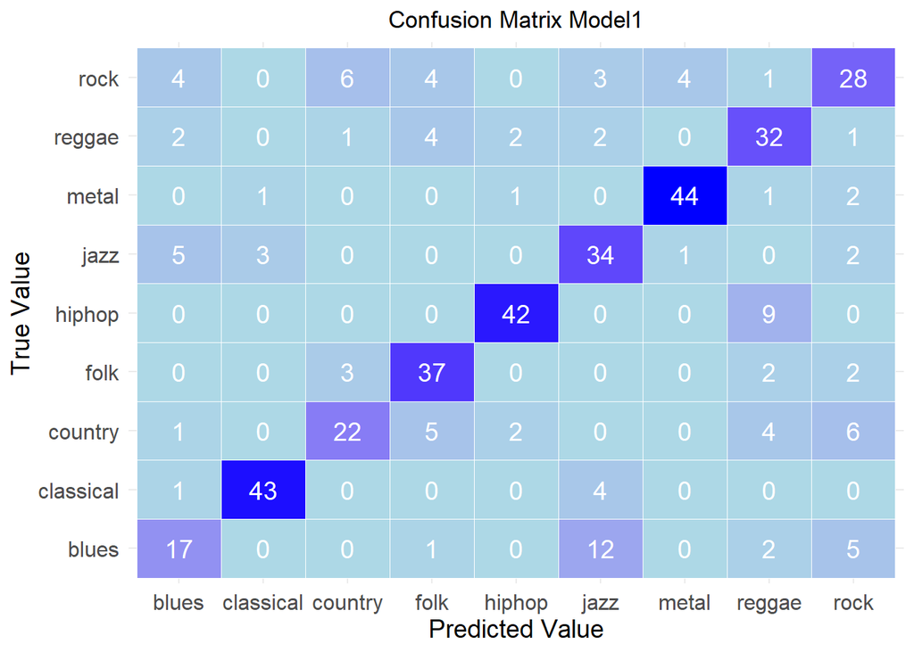

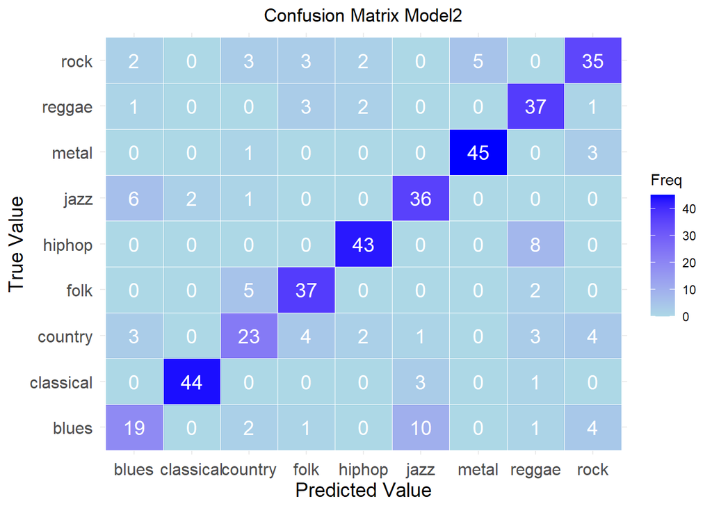

Many interesting conclusions can be drawn from the charts above:

Because I didn’t remove the variable determining the song title from the dataset, I can now look more closely at individual errors. What caught my attention the most was one jazz track that was confused with a metal track in `Model1`.

| track.name | genre | .pred_class |
| --- | --- | --- |
| Inner Urge - Rudy Van Gelder Edition; 2004 Digital Remaster | jazz | metal |

[video not shown]

After listening to it, it becomes understandable why the model made a mistake in this case. It is a fast, aggressive, and gloomy track, and although it’s jazz, it has elements of metal. `Model2` no longer made this mistake; one can suspect that this happened due to restoring the `acousticness` variable in the dataset - it is a feature that definitely distinguishes these genres from each other, and most likely the information it brought into `Model2` eliminated this confusion.

Another mistake that can be examined is a jazz track classified as country in `Model2`.

| track.name | genre | .pred_class |
| --- | --- | --- |
| The Sidewinder - Remastered 1999/Rudy Van Gelder Edition | jazz | country |

[video not shown]

After listening to it, the mistake can also be understood. It is definitely a jazz track, but it simultaneously sounds a bit like a “song from a western”.

There are also errors present here for which there is no logical explanation, such as classifying Linkin Park’s “What I’ve Done” as country, or Vivaldi’s composition as reggae.

| track.name | genre | .pred_class |
| --- | --- | --- |
| What I've Done | metal | country |

| track.name | genre | .pred_class |
| --- | --- | --- |
| Recomposed By Max Richter: Vivaldi, The Four Seasons: Spring 1 - 2012 | classical | reggae |

### ROC Curve Charts

**Display code**

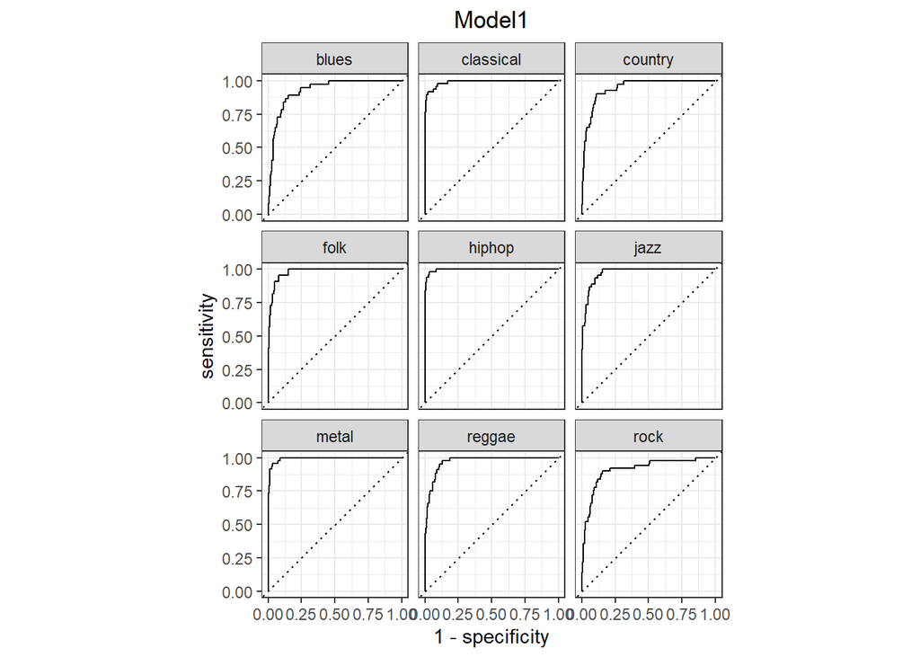

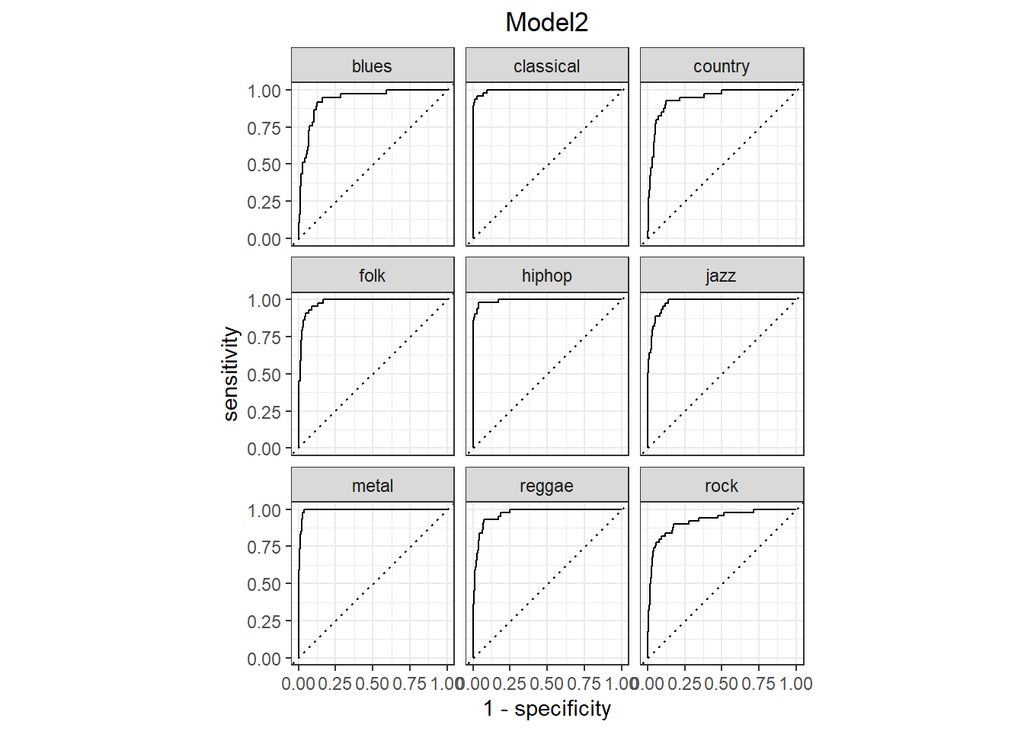

```r
rf_wflow %>%
  last_fit(split) %>%
  collect_predictions() %>%
  roc_curve(truth = genre, .pred_blues, .pred_classical, .pred_country, .pred_folk, .pred_hiphop, .pred_jazz, .pred_metal, .pred_reggae, .pred_rock) %>%
  autoplot() + labs(title = "Model1") +
  theme(plot.title = element_text(hjust = 0.5))
rf_wflow2 %>%
  last_fit(split2) %>%
  collect_predictions() %>%
  roc_curve(truth = genre, .pred_blues, .pred_classical, .pred_country, .pred_folk, .pred_hiphop, .pred_jazz, .pred_metal, .pred_reggae, .pred_rock) %>%
  autoplot() + labs(title = "Model2") +
  theme(plot.title = element_text(hjust = 0.5))
```

From the ROC curves created using the one vs. all method for each genre, one can find confirmation of what could already be seen on the confusion matrix - the model performed best in predicting metal and hip-hop, while it performed worst in classifying blues, rock, and country.

## Feature Importance in the Model

**Display code**

```r
f_imp <-
  rf_wflow %>%
  last_fit(split) %>%
  extract_fit_parsnip() %>%
  vip(num_features = 13)

f_imp2 <-
  rf_wflow2 %>%
  last_fit(split2) %>%
  extract_fit_parsnip() %>%
  vip(num_features = 15)
```

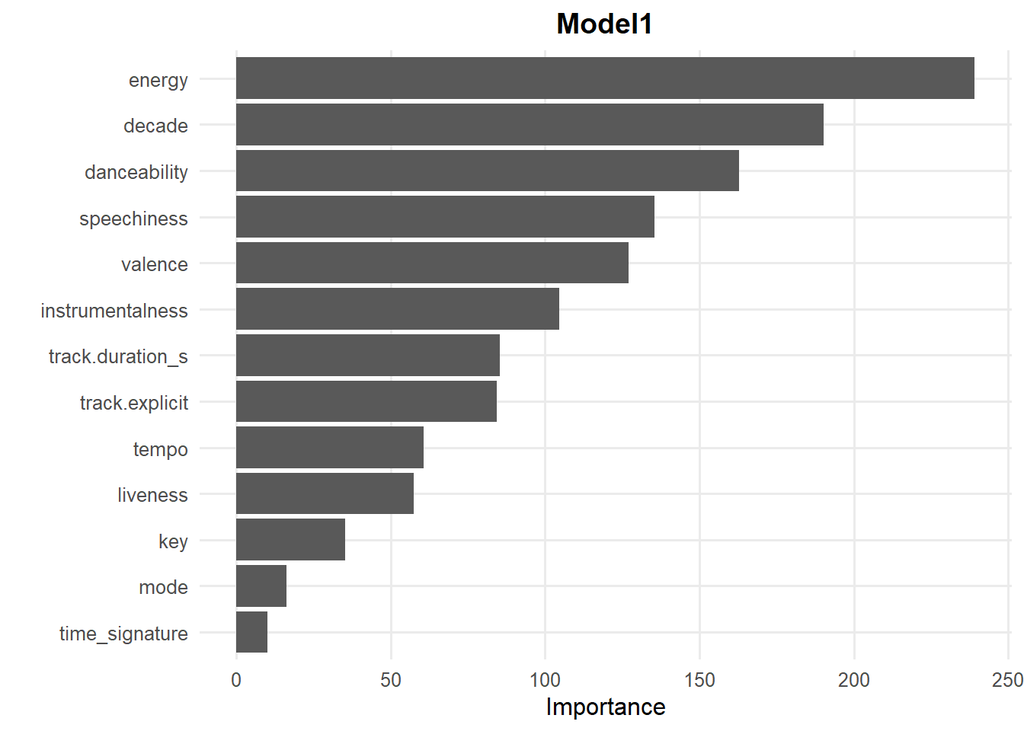

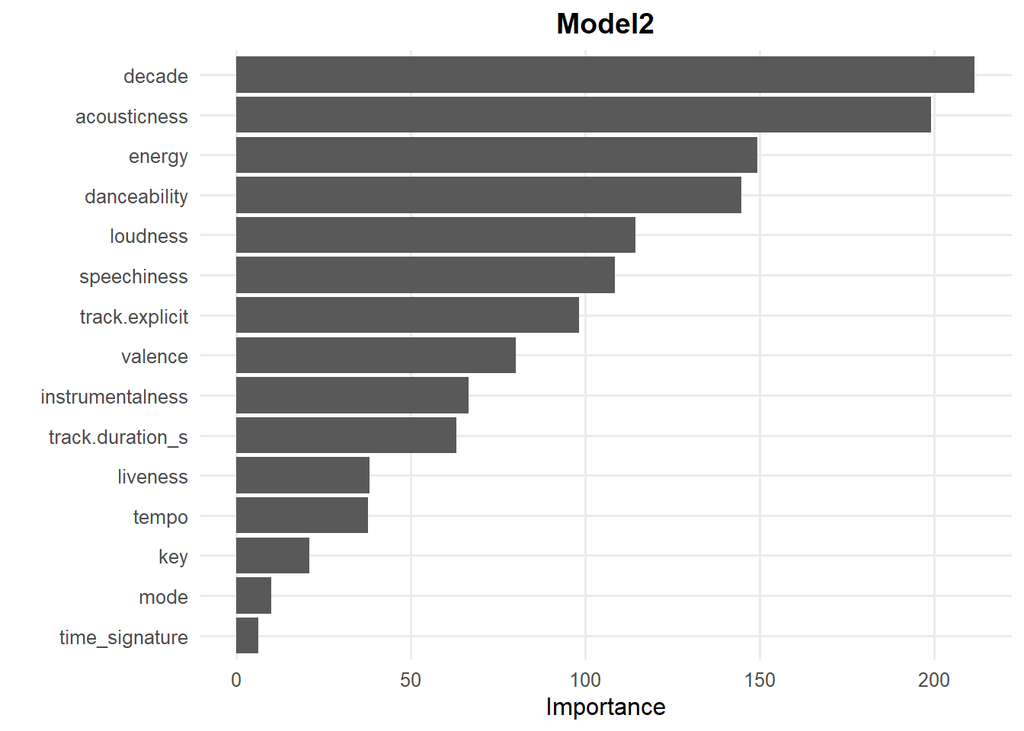

In both cases, the least useful variables were `key`, `mode`, and `time_signature`, which is not a surprise, since genres are never limited to specific scales or structures.

Another important conclusion can be drawn from the chart above: since decade turns out to be a significant variable, one can assume that the created models would not perform well in classifying tracks outside the dataset on which it was built. The tracks in the dataset were not selected randomly – I personally selected the playlists they come from. They were often limited to specific decades, as evidenced by their names, such as “10s Metal Classics”. Consequently, it cannot be assumed that the number of tracks from a given genre in the dataset is representative of the entire genre. For this reason, the model would probably not be as effective if tested on a completely different test dataset, because it would be confused by release dates, to which it could not apply the rules that worked so well in the context of tracks from my dataset.

# Summary

### Sources

- https://www.blisshq.com/music-library-management-blog/2011/01/25/fundamental-music-genre-list/
- https://developer.spotify.com/documentation/web-api/reference/get-audio-features